# HW8

```python
# import packages

import hydrodata.point_observations.pandas.collect_observations as point_obs
import hydrodata.point_observations.utilities as utilities

import hydrodata.point_observations.pandas.collect_observations as point_obs
from matplotlib import pyplot as plt
import pandas as pd
import numpy as np
```

```python
# constants
L = 100          # Hillslope length (m)
S0 = 0.05        # slope
h0 = 0.0         # initial pressure- initial condition (m)
n = 0.036        # Manning's number s/m^(1/3)
t_rain = 1080    # rain duration (s)
q = 0.00000556   # rain rate (m/s)
t_total = 3600   # total simulation time (s)
deltax = 10      # deltax (m)
tinit = 0.0      # initial time (s)
```

## Part 1: explicit, finite difference approximation

Use the explicit, finite difference approximation to solve the system. Plot the total runoff at the end of the hillslope for the entire simulation period. Also plot the head distribution along the hillslope at three meaningful times (chosen by you). Start with a ∆x=10.0 m and choose ∆t based on CFL criteria and show your steps to determine a stable ∆t.

### Calculate flow using pressure

I use the following equation from the class lecture notes to solve for flow L^2/T and for velocity L/T: $$q = \frac{\sqrt{S_0}h^{5/3}}{n}$$

$$v = \frac{\sqrt{S_0}h^{2/3}}{n}$$

```python
# function for flow and velocity
def flow(SKNOT,H,N):
    return (np.sqrt(SKNOT)*H**(5/3))/(N)

def velocity(SKNOT,H,N):
    return (np.sqrt(SKNOT)*H**(2/3))/(N)
```

Now I use the finite differences approach to calulate pressure height at each time and location along the hill

```python
# Setting arrays for the finite difference approach
# arbitrarily set deltat = 30 sec
deltat = 30 # seconds
NX = int(L/deltax)                  # length of our array to model the x-direction of the hill
NT = int(t_total/deltat)            # length of our array to model time
h = np.zeros((NX,NT))           # array of pressure heights
time = np.arange(0,t_total,deltat)  # array of time values
```

```python
told = tinit # old time

# looping through all time and space to get the finite difference solution
for j in range(0,len(time)-1):
    tnew = told + deltat

    # middle conditions (using our finite difference approximation)
    for i in range(1, NX):
        # update Hnew vector from discretized PDE stencil

        # first consider the early time period when it is raining (q is nonzero)
        if tnew <= t_rain:
            h[i,j+1] = h[i,j] - (deltat*np.sqrt(S0)/n)*((h[i,j]**(5/3))- (h[i-1,j]**(5/3)))/deltax + q*deltat


        # now consider the case when it is not raining (q is zero)
        else:
            h[i,j+1] = h[i,j] - (deltat*np.sqrt(S0)/n)*((h[i,j]**(5/3))- (h[i-1,j]**(5/3)))/deltax + 0.0

    # Prepare for the next time through the loop.
    told = tnew
```

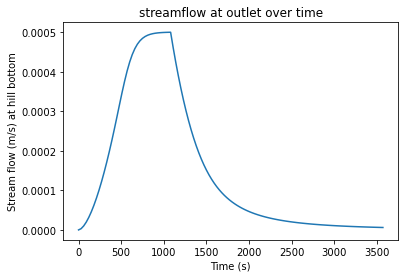

```python
# calculate velocity at the bottom of the hill using the function above and plot it
v_finite_difference = flow(S0, h[NX-1,:], n)
plt.plot(time,v_finite_difference)
plt.xlabel("Time (s)")
plt.ylabel("Stream flow (m/s) at hill bottom")
plt.title("streamflow at outlet over time")
plt.show()
```

Below I plot head distribution at 3 different times as described below:

- time 1 = 200 seconds, where we can see the streamflow is building up due to rain
- time 2 = 800 seconds, while the streamflow is in steady state
- time 3 = 2500 seconds, after the rain has stopped and streamflow is receding

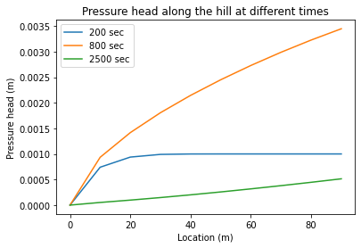

```python
# array for x distance
x = np.arange(0,L,deltax)  # array of time values
plt.plot(x,h[:,np.int(200/deltat)], label="200 sec")
plt.plot(x,h[:,np.int(800/deltat)], label='800 sec')
plt.plot(x,h[:,np.int(2500/deltat)], label='2500 sec')
plt.xlabel("Location (m)")
plt.ylabel("Pressure head (m)")
plt.title("Pressure head along the hill at different times")
plt.legend()
plt.show()
```

I see that pressure head increases down the hill. I also see that the entire hill experiences the highest pressure head at steady state.

### Determining stable deltat

To determine a stable $\Delta t$, I use the following CFL condition $$\frac{v\Delta x}{\Delta t} \le 1$$ Solving for $\Delta t$ I find the following: $$v \Delta x \le \Delta t $$ So I will pick a $\Delta t$ that is greater than this criteria.

To pick a stable solution I will pick the velocity at the bottom of the hill during the steady state period (800 sec- where it is likely to be highest in all space and time for our simulation). This will yield a proper stable solution.

```python
# determine deltat using CFL criteria
v_stable = velocity(S0, h[NX-1,np.int(800/deltat)], n)

deltat_min = v_stable * deltax
print(f'The minimum value for deltat is {deltat_min} s')
```

```
The minimum value for deltat is 1.418054504474415 s
```

Since the minimum deltat value that ensures stability is 1.4 seconds, my initial choice of 30 seconds satisfies the CFL stability condition.